# The Effectiveness of Membership-Based Free Shipping: An Empirical Investigation of Consumers’ Purchase Behaviors and Revenue Contribution

Converted from PDF `Guo-MembershipFreeShipping-2023-JM.pdf` · 21 pages · anchors: page `#pN`, block `#pN-bK`

Page 1

The Effectiveness of Membership-Based Free Shipping: An Empirical Investigation of Consumers’ Purchase Behaviors and Revenue Contribution

#### Fangfei Guo and Yan Liu

Abstract Membership-based free shipping (MFS) has been increasingly adopted by online retailers. However, its effectiveness is understudied. This study leverages a consumer transaction data set provided by an online retailer and uses a stacked difference-in-differences approach to quantify the enrollment effect of MFS on consumers’ purchase behaviors and their net revenue contribution to the retailer. Interestingly, MFS enrollment does not lift average consumers’ spending at the beginning of the enrollment, as they break large orders into smaller ones. Retailers do not gain incremental net revenue due to the increased shipping costs during this period. However, the free shipping benefit may build a switching barrier that motivates consumers to purchase more often with larger order sizes over time. It eventually leads to increased spending and revenue contribution. MFS also increases members’ purchase variety and impulse purchases. In addition, the authors find that there is a greater increase in net revenue contribution after enrollment for light buyers, variety seekers, and those who are willing to pay shipping fees before enrollment. Surprisingly, MFS has a negative impact on the revenue contribution of heavy buyers, the conventional best-value consumers. Moreover, MFS can effectively strengthen consumer–retailer relationships by reducing customer churn.

Keywords shipping policy, membership program, online retailing, staggered treatment effect, difference-in-differences

Online supplement: https://doi.org/10.1177/00222429231158116

With the proliferation of e-commerce, one of the challenges retailers face is recovering the constantly increased shipping costs. As Amazon’s annual report shows, its shipping costs reached $83.5 billion in 2022, an increase of about 200% over the previous five years (Amazon 2022). With the hope of satisfying consumers’ expectations of free shipping while recovering high shipping costs, online retailers have shown a growing interest in membership-based free shipping (MFS), in which consumers pay an upfront membership fee in exchange for unlimited free shipping. Nearly 40% of the world’s top retailers have adopted MFS or advertised it as a premium service in their membership programs (Freedman 2022).

Whereas some retailers, such as Walmart, ASOS, and Sephora, introduced MFS with few added perks other than free shipping, other retailers have integrated MFS into their subscription programs (Table 1). For example, Best Buy provides members with tech support, and Bed Bath & Beyond offers member price discounts, along with MFS. Recent literature

has examined the effects of such an integrated subscription program on incremental sales and profits (Iyengar, Park, and Yu 2022). However, Iyengar, Park, and Yu (2022) suggest that the free shipping benefit is not likely the driver for sales change because other perks (e.g., member price discounts) are more important for members of these subscription programs. On the contrary, industry experts claim that MFS is quite successful and that unlimited free shipping is the main reason that drives consumers to join a subscription program such as Amazon Prime (Freedman 2022). Given that MFS requires retailers’ long-term commitment and carries substantial direct costs, a critical research priority is to isolate the effects of MFS from those of benefits unrelated to shipping and

Fangfei Guo is Assistant Professor of Marketing, Poole College of Management, NC State University, USA (email: fguo9@ncsu.edu). Yan Liu (corresponding author) is Associate Professor of Marketing, Mays Business School, Texas A&M University, USA (email: yliu@mays.tamu.edu).

Article

Journal of Marketing 2023, Vol. 87(6) 869-888 © American Marketing Association 2023

Article reuse guidelines: sagepub.com/journals-permissions DOI: 10.1177/00222429231158116

journals.sagepub.com/home/jmx

Page 2

Table 1. Shipping Policies from Representatives of Worldwide Retailers.

Retailer Name Country

Shipping Policies

Contingent Free

Shipping

Membership-Based Free Shipping

Unlimited

Free Shipping Free Shipping Price Discount Perks Unrelated

to Price

Walmart United States ✓ ✓

Sephora United States ✓ ✓

ASOS United Kingdom ✓ ✓

Selfridges United Kingdom ✓ ✓

Tesco United Kingdom ✓ ✓

Bol.com European Union ✓ ✓

Zalando European Union ✓ ✓

Vip.com China ✓ ✓

Tippsy United States ✓ ✓

Rue La La United States ✓

eBay Australia ✓

Zazzle United States ✓

Gilt United States ✓

Barnes & Noble United States ✓ ✓ ✓

Bed Bath & Beyond United States ✓ ✓ ✓

CVS United States ✓ ✓ ✓

Wayfair United States ✓ ✓ ✓

Best Buy United States ✓ ✓ ✓ ✓

JD.com China ✓ ✓ ✓ ✓

Amazon United States ✓ ✓ ✓

Kohls United States ✓

JC Penney United States ✓

Apple United States ✓

Dell United States ✓

Nordstrom United States ✓

Notes: Price discount refers to the constant discount for most items. Different retailers offer different perks unrelated to product price, such as free music and video (Amazon), premium tech support (Best Buy),

coupons for entertainment and hotels (JD.com), and so on. Please note that some listed retailers added perks other than free shipping later. For example, Walmart Plus added a streaming service on August 15,

2022. However, the initial benefit offered by these retailers was unlimited free shipping.

870 Journal of Marketing 87(6)

Page 3

understand the implications of this popular shipping policy on consumers’ purchase behavior as well as retailers’ profitability.

In the current study, we intend to fill this research gap and investigate a fee-based membership program that offers only one benefit to its members, unlimited free shipping. We first ask to what extent MFS enrollment could increase consumers’ spending, one of the most crucial success indicators of any membership program (Lal and Bell 2003). On the one hand, when consumers pay membership fees, they are inspired to gain a greater return on their initial investment by purchasing more (Ailawadi, Ma, and Grewal 2018). Thus, MFS enrollment may motivate consumers to consolidate their purchases with the retailer, leading to more sales revenue. On the other hand, consumers may take advantage of unlimited free shipping by placing frequent and small orders without spending more. Therefore, an important question remains unanswered: how MFS enrollment changes consumers’ purchase behaviors related to how much to buy, including total spending, purchase frequency, and average order size.

When shopping online, consumers can easily access millions of products, and shipping policies could change consumers’ purchase intentions in different product categories (Shehu, Papies, and Neslin 2020). One interesting fact about top retailers that have adopted MFS is that they also offer contingent free shipping (CFS) to consumers who choose not to enroll in MFS (Freedman 2022). In CFS, consumers get free shipping with a minimum spending requirement, which may limit their purchases within certain product categories that can easily meet the requirement (Chen and Ngwe 2017). When the free shipping requirement is removed, MFS members may explore more product categories with different price levels. In addition, free shipping might stimulate them to make impulsive purchases to add unplanned products to their baskets (Dawson and Kim 2009). Thus, we investigate how MFS changes consumers’ purchase behaviors related to what to buy, including purchase variety and purchase of impulse products (referred to as impulse purchases).

The free shipping benefits of MFS bring enormous shipping costs to retailers, especially when consumers have their orders shipped in a myriad of small packages (Sun, Cavusoglu, and Raghunathan 2022). Retailers hope membership fees can recoup shipping costs. However, the value implications of membership programs are inconclusive in the literature (Fang et al. 2021; Sun, Cavusoglu, and Raghunathan 2022) and in real-world business. For example, Costco’s annual membership fees account for 80% of Costco’s gross margin (Lewis 2016), while an estimate for Amazon Prime shows that it lost at least $11 per member after accounting for the membership fee (Tuttle 2013). We thus further investigate the net customer revenue (NCR), defined as the revenue generated from consumer transactions and membership fees minus the shipping cost paid by the retailer, to shed light on the financial outcome of MFS.

Taking these factors together, we examine the effect of MFS enrollment on consumers’ purchase behaviors related to how much to buy (i.e., total spending, purchase frequency, and average order size), what to buy (i.e., purchase variety and

impulse purchases), and NCR with an order-level transaction data set. The data set is provided by a top online retailer in Asia, which launched MFS during the sample period. Consumers pay an annual membership fee to enroll in MFS and get the sole membership benefit, unlimited free shipping on all orders. The data set spans 22 months before and 14 months after the launch of MFS. To estimate the MFS enrollment effect and its trend over time, we compare the purchase behaviors and revenue contributions of members with those of nonmembers before and after their enrollment date by using a quasi-experimental design with a difference-in-differences (DiD) approach and propensity score matching (PSM). We employ a time-varying instrumental variable with a control function approach to control for the endogeneity of enrollment timing. Given that members’ enrollment occurs at different times, we adopt a stacked DiD approach that circumvents the problem of staggered treatment timing (Baker, Larcker, and Wang 2022; Cengiz et al. 2019). Moreover, we take a further step to identify varying responsiveness among customer segments. In additional analyses, we examine whether MFS enhances customer retention to shed light on the effectiveness of MFS in the long run.

Our research primarily contributes to the literature on shipping policies and offers important managerial implications for practitioners in the following ways. First, using extensive consumer transaction data, we are among the first to examine the effect of an emerging free shipping policy—MFS—on consumers’ purchase behaviors. We find that MFS is surprisingly ineffective in increasing overall spending for average consumers during the membership period, as members take advantage of free shipping benefits to break large orders into smaller ones. Moreover, MFS changes consumers’ purchase variety and the component of shopping baskets; that is, members purchase from broader product categories and enjoy impulsive purchases.

Second, we expand the scope of the membership program literature from free-to-join programs to paid programs. We provide empirical evidence on the importance of membership fees. A membership fee serves as more than just a steady revenue source for retailers. Membership fees might be perceived as sunk costs and switching costs in consumers’ mental accounts, effectively preventing them from switching to alternatives and enhancing customer retention. Our findings on the dynamic effect of MFS (i.e., that members’ spending and revenue contribution gradually increase over time) might be due to the positive effect of switching costs. Moreover, we find that light buyers, who are the most willing to pay shipping fees or purchase from the broadest product categories before enrollment, are the most responsive customer segment, having the highest percentage change of revenue contribution after enrollment. In contrast, heavy buyers, normally regarded as the best-value segment, have no significant increase in their revenue contribution after enrollment as they are most likely to exploit free shipping. The MFS program even loses money from heavy buyers who are unwilling to pay the shipping fee or purchase from limited product categories before enrollment. These findings provide guidance for retailers to conduct segment-based targeting.

Guo and Liu 871

Page 4

Lastly, we demonstrate that MFS is an effective marketing instrument to increase customer retention. It is particularly helpful in increasing the retention of consumers who seek to purchase from diverse product categories. These findings also add evidence to support the effectiveness of shipping policies for customer retention (Lewis 2006).

#### Institutional and Conceptual Background Institutional Background

Shipping fee is an essential component of the marketing mix (Lewis, Singh, and Fay 2006). It is also one of the leading reasons that drive consumers to abandon their shopping carts in the United States (Statista 2022). In this situation, free shipping has become a necessary incentive to stimulate consumers’ online purchases (Lewis 2006). Among top retailers that offer free shipping, only 17.5% offer free shipping on all orders (Freedman 2022). In comparison, over 65.4% of them offer free shipping under certain conditions, such as CFS and MFS, to retain consumers and recover shipping costs (Freedman 2022).

CFS is one of the most popular free shipping policies. It can lead to greater sales revenue since consumers need to buy more to get free shipping. According to a recent survey, 58% of consumers have added items to their shopping carts to qualify for free shipping (Comscore 2014). However, CFS may reduce store traffic (Lewis, Singh, and Fay 2006) when consumers purchase extra items and use them in the future. To compensate for CFS’s disadvantage while increasing retailers’ competitive advantage, retailers have begun to roll out MFS on top of CFS. Some retailers offer MFS with few added perks other than free shipping (Table 1). Other retailers integrate MFS into their subscription programs with additional benefits, such as streaming service with Amazon Prime. The retailer we study belongs to the former group, and the only member benefit is unlimited free shipping.

#### Literature Review

Free shipping promotion and CFS. Prior research has shown that shipping costs greatly influence consumers’ purchase frequency and order size. Using transaction data from an online grocer and drugstore, Lewis, Singh, and Fay (2006) examine the impact of different shipping fee schedules on consumers’ order incidence and order size. They find that free shipping promotion and CFS effectively boost sales, but the loss of shipping revenue and high shipping costs render these shipping structures unprofitable to retailers.

Similarly, Lewis (2006) finds that free shipping promotion leads to the highest order incidence with the smallest order size, and CFS always outperforms free shipping promotion in acquiring consumers and increasing retailers’ profits. Yang, Essegaier, and Bell (2005) also conclude that CFS influences consumers’ purchase behavior more effectively than free shipping promotions. Chen and Ngwe (2017) reveal that retailers should modify prices according to different product categories

when changing free shipping thresholds. More recently, Shehu, Papies, and Neslin (2020) find that free shipping promotions are unprofitable, as they may lead to increased product returns.

Membership-based free shipping. A limited number of gametheoretical studies have started to examine the performance of MFS. Sun, Cavusoglu, and Raghunathan (2022) study how MFS affects a single shipping platform (e.g., eBay) and its thirdparty sellers’ profits. They find that MFS can induce high demand and product price, benefiting both sellers and the platform. In another theoretical work, Fang et al. (2021) compare three shipping policies, including paid shipping, CFS, and MFS, in a duopolistic setting and focus on retailers’ optimal pricing schemes under different shipping policies. They conclude that the costs of free shipping cannot be recovered in general. Our study differs from these previous studies by quantifying the MFS enrollment effect on consumers’ actual purchase behaviors from multiple dimensions with real-world data.

Subscription program. Our study also relates to research on feebased subscription programs. Wagner, Pinto, and Amorim (2021) examine a subscription-based free delivery program in a grocery store setting and suggest that it hurts grocery stores’ profits because of picking costs, delivery costs, and cannibalization of in-store sales. Since consumers’ daily needs for groceries from local stores are less likely to change with free delivery, their findings offer limited implications for understanding consumers’ purchase behavior when shopping online for large varieties of products (e.g., electronics, clothing, personal care). Moreover, the cost structure of local grocery delivery differs from the shipping costs of online purchases, leading to different financial outcomes for retailers. Another related study is by Iyengar, Park, and Yu (2022). They study a subscription program for an online retailer and conclude that it can generate incremental sales and profits. Our study differs from that of Iyengar, Park, and Yu in two ways. First, Iyengar, Park, and Yu examine a subscription program offering many other benefits beyond free shipping to members, including gift cards and member discounts. More importantly, they find that the free shipping benefit “is not likely the driver of the observed effects” (Iyengar, Park, and Yu 2022, p. 1111), while other benefits are the reasons for the change in sales. This is not surprising, as free shipping is a less important benefit in their research context. For this retailer, which specializes in personal care products (e.g., skin care), the large majority of the orders satisfied free shipping requirements, regardless of being purchased by members or nonmembers. Due to the nature of their empirical context, Iyengar, Park, and Yu cannot offer insight into the focal research question of this study, that is, how MFS influences consumers’ purchase behaviors and revenue contribution. The MFS program we study offers the sole benefit of free shipping and thus allows us to isolate its effect. Secondly, the subscription program studied by Iyengar, Park, and Yu is almost free to members as they receive a no-restriction gift card that equals the amount of the annual subscription fee upon activation

872 Journal of Marketing 87(6)

Page 5

of the membership. As a result, their findings have limited value in terms of implications for retailers that rely on membership fees as an important source of revenue. In addition, such a difference in the true cost of membership may also lead to consumers’ different mental accounting and purchase behaviors.

#### Effects of MFS Enrollment on Consumers’ Purchase Behaviors

In this study, we focus on the following consumer purchase behaviors: how much to buy (i.e., total spending, purchase frequency, and average order size) and what to buy (i.e., purchase variety and impulse purchases). Prior literature on membership programs suggests that program-related factors, such as requirements for participation and reward design, affect consumers’ purchase behaviors (e.g., Liu and Yang 2009). The two salient and unique characteristics of MFS—an upfront membership fee and unlimited free shipping—may be linked to three behavioral theories, including switching cost effect, sunk cost effect, and no-minimum free shipping effect, and help us predict the impact of MFS on consumers’ purchase behaviors (Figure 1). Please note that our goal is to use these theories to predict the effect of MFS, not to test any specific theory.

Switching cost effect. Prior literature suggests that membership programs can lock in consumers by increasing switching costs (Henderson, Beck, and Palmatier 2011). In the context of MFS, consumers face both high economic and noneconomic switching costs. The economic switching costs are constituted by the initial investment (i.e., membership fees) and the savings from free shipping benefits (Leenheer et al. 2007). The noneconomic switching costs include learning cost (i.e., learning about another retailer), search cost (i.e., searching for equivalent free shipping promotions and price discounts), and psychological cost (i.e., giving up satisfaction and trust with the retailer) (Dick and Basu 1994). A well-established finding from previous literature is that switching costs increase consumer repurchase attention and enhance consumer engagement. Switching costs drive repeat purchases, leading to an increased

wallet share (Bolton, Kannan, and Bramlett 2000). They could also moderate the relationship between important determinants, including consumer-perceived value (e.g., Yang and Peterson 2004) and satisfaction. Therefore, switching costs also have a profound explanatory effect on consumers’ attitudes toward the retailer. Because of the increased purchase intention and enhanced positive attitude toward the retailer, we expect that consumers’ spending may increase after MFS enrollment. Moreover, as satisfied consumers’ goodwill and trust increase their intention to expand their purchase scope, they may purchase categories previously not bought from the retailer, resulting in an increased purchase variety and purchase of impulse products.

Furthermore, since it takes time for consumers to develop positive perceptions and attitudes toward the retailer (Dick and Lord 1998), the effects of switching costs might intensify over time. Thus, the increase in consumers’ spending, purchase frequency, purchase variety, and impulsive purchases over time could be explained by the increasing effects of switching costs.

Sunk cost effect. The upfront membership fee is an irreversible cost in consumers’ mental accounts. It represents a sunk cost, which has been shown to be very effective in encouraging consumers to commit to their prior choices (Dick and Lord 1998). Once the membership fee has been paid, consumers have a greater tendency to continue utilizing their membership benefits to maximize their investment (Ailawadi, Ma, and Grewal 2018). Moreover, to justify the money spent on membership fees, consumers will form a positive attitude toward their chosen retailer (Ashley, Gillespie, and Noble 2016), affecting their long-term commitment (Dick and Lord 1998). Therefore, we expect that the sunk cost of membership fees should have similar effects on consumers’ purchases as the switching cost effect. That is, an increase in members’ spending, purchase frequency, purchase variety, and purchase of impulse products might be partly explained by the sunk cost effect.

However, different from switching costs, sunk costs may become less salient over time (Iyengar, Park, and Yu 2022). Although consumers tend to immediately escalate commitment

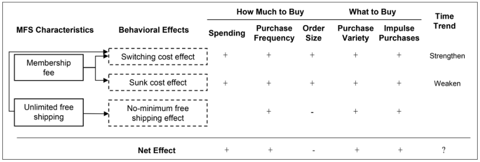

NOTE: figure/graphic rendered as an image from the PDF; its content is not machine-readable text. Caption (if any) follows as the next block.

Figure 1. Behavioral Effects on Consumers’ Purchase Behaviors.

Guo and Liu 873

Page 6

in response to a previous investment, this tendency reverses over time (Heath 1995). Therefore, the psychological effect of sunk cost on a consumer’s mental account and purchase behaviors may wear off. Thus, when members’ responsiveness to MFS decreases over time, it could be explained by the weakened sunk cost effect.

No-minimum free shipping effect. Consumers are sensitive to shipping fees and thus very responsive to free shipping promotions (Lewis, Singh, and Fay 2006). Recall that, in our empirical setting, the retailer offers CFS to nonmembers. Compared with nonmembers, MFS members could enjoy the no-minimum free shipping and thus have no incentive to place large orders (Lewis 2006; Lewis, Singh, and Fay 2006). As a result, consumers may purchase more frequently with smaller order sizes after enrollment. Therefore, consumers’ total spending is expected not to change.

No-minimum free shipping may also affect consumers’ decisions on what to buy. Consumers often concentrate their purchases within limited product categories to meet the CFS threshold or minimize shipping fees (Chen and Ngwe 2017). With MFS, consumers are more likely to explore various product categories with different price levels to fit their true preferences (Rothschild 1974). We thus expect MFS members to increase their purchase variety. No-minimum free shipping also reduces consumers’ transaction costs. Such monetary benefit can effectively stimulate consumers’ impulse purchases as it alleviates their guilt about buying unplanned items (Khan and Dhar 2010). However, it may not directly affect consumers’ purchase of nonimpulse products, as these are necessities that consumers will buy regardless of the shipping fee. We thus expect an increased share of impulse products.

Overall, we expect a positive impact of MFS on consumers’ spending, purchase frequency, purchase variety, and purchase of impulse products because of the switching cost effect, sunk cost effect, and no-minimum free shipping effect. We expect that the no-minimum free shipping effect negatively impacts members’ order size as unlimited free shipping is the main reason consumers enroll in MFS, leading to a smaller order size. Moreover, we are not sure how the effects of MFS on consumers’ purchase behaviors change over time because of the opposite time trends of the switching cost effect and the sunk cost effect. We thus leave it to the empirics to determine the directions of these effects (Golder et al. 2023). In addition, we expect heterogeneous effects of MFS on consumers’ purchase behaviors and revenue contribution. Therefore, the effects discussed previously could be moderated by consumer characteristics, such as preenrollment spending, purchase variety, and willingness to pay shipping fees.

#### Data Overview

We obtained consumer order-level transaction data from a major online retailer in Asia, one of the top ten online business-to-consumer platforms in terms of market share. It carries various products, including apparel, electronics, beauty products, home goods, and books. The retailer provided us with 36 months of consumer transaction data. A crucial feature of this

data set is that the retailer launched MFS in the 22nd month of the observation period. To enroll in MFS, consumers pay an annual membership fee in exchange for unlimited free standard shipping on all orders, the only benefit provided by the program. Before the launch of MFS, the retailer offered CFS to all consumers. The CFS still applies to consumers who choose not to enroll in MFS. The CFS threshold was kept the same during the observation period. The launch of MFS was announced via multiple marketing channels, such as the retailer’s website, opt-in email, and media news. After that, the retailer did not engage in targeted promotions for members during the observation period, and there was no price discrimination between members and nonmembers. Other than the shipping policy, no significant business changes occurred during our observation period.

For data privacy and security reasons, the retailer randomly drew consumers from its database. Our data set contains consumer transaction information, including consumer ID, order ID, order type, purchase date and time, delivery method, shipping fee, product category, brand, quantity, transaction amount, promotion indicator, and zip code. To ensure the data are valid for estimating the effects of MFS enrollment, we apply the following criteria for consumer inclusion. First, we only include consumers who made at least one purchase before and after the MFS launch. This restriction ensures that we observe consumers’ purchase behavior before their MFS enrollment and that the estimations are not biased because of early churn. Second, we only include members who enrolled in MFS at least six months before the end of the sample period, which is necessary to analyze the dynamic impact of MFS enrollment. Third, we exclude outliers, who are possible third-party buyers and have made over 300 orders per year from a single product category, and consumers who have exclusively purchased digital items such as electronic gift cards and e-books, to which shipping policies are not applicable. Only .78% (20 members and matched nonmembers) of the sample are third-party buyers. They often make very large and frequent orders that satisfy free shipping regardless of their membership status. We thus expect MFS to have minimal effects on them. A robustness check including them in the sample confirms our expectation (Table W10 of Web Appendix A). After the filtering process, the final sample contains 5,354 consumers (2,225 members and 3,129 nonmembers) who made 176,602 orders during our data period. The order-level transaction data include a prelaunch period of 22 months and a postlaunch period of 14 months.

#### Variable Operationalization

We list the variable operationalization in Table 2 and begin with the outcome variables.

#### Outcome Variables: Consumers’ Purchase Behaviors and Net Customer Revenue (Yit)

We define two sets of outcome measures related to consumers’ purchase behaviors, including how much to buy and what to buy, and an outcome measure of NCR.

874 Journal of Marketing 87(6)

Page 7

How much to buy. We first measure a consumer’s total spending (defined as the purchase amount in a given month). As total spending is determined by purchase frequency and order size, which may change with different shipping policies (Lewis, Singh, and Fay 2006), we thus include purchase frequency (defined as the number of orders in a month) and average order size (defined as average purchase amount in each order) as two other measures.

What to buy. We investigate the purchase variety and types of products affected by MFS enrollment. Purchase variety is measured as the number of distinct product categories a consumer purchases. Moreover, we follow previous literature and group products into impulse and nonimpulse products. Impulse products are the product categories that are more likely to trigger consumers’ spontaneous and unreflective purchases. These purchases are often made “on a whim” or when the urge is high (Narasimhan, Neslin, and Sen 1996, p. 22; Rook and Fisher 1995). In contrast, nonimpulse products are the product categories that consumers normally purchase or are necessities on their current shopping list (Rook and Hoch 1985). Specifically, we followed Narasimhan, Neslin, and Sen (1996) and Srinivasan et al. (2004) and asked consumers to rate each product category on a set of impulse scale items in a survey. We report the survey design in Web Appendix B. The categories with an impulse rating above 4 (a total of seven scales) are classified as impulse products. Specifically, impulse products include apparel, shoes, food, cosmetics/beauty/luxury beauty products, jewelry, and mobile/video games/DVDs/music, and nonimpulse products include musical instruments, automotive products, cameras, laptops and computers, electronics, bags/ luggage, wine, home/office/kitchen appliances, personal care appliances, watches, books, pet products, kid/baby products, sports equipment, outdoor items, and garden appliances and tools.<sup>1</sup> Our classification is similar to that of Xu et al. (2017), confirming the validity of the survey. We then define impulse purchases as the percentage of spending on impulse products.

Net customer revenue. Free shipping may increase demand but shift high shipping costs to retailers (Sun, Cavusoglu, and Raghunathan 2022). Thus, NCR is not apparent, as it is determined by the balance between the revenue generated from sales and membership fees and the costs of free shipping. To assess the NCR, we account for (1) the revenue generated by the consumers’ purchases, (2) the revenue from the shipping fees paid by consumers, (3) the revenue from membership

fees,<sup>2</sup> and (4) the shipping costs paid by the retailer. Specifically,

NCRit =

(Spendingijt −SCij)+MFit, Members,

(Spendingijt +SF×I(Sizeijt <CF)ij −SCij), Nonmembers,

(1)

where NCRit is the net revenue contribution of consumer i at month t. Spendingijt is consumer i’s purchase amount in order j at month t. SCij is the shipping costs absorbed by the retailer. We obtain zip code–level average shipping costs per order for members and nonmembers from the retailer.<sup>3</sup> SF is a flat shipping fee paid by nonmembers when the order size, Sizeijt, is smaller than the CFS free shipping threshold, CF. MFit is the monthly fee paid by consumer i at month t after enrollment. I(Sizeijt < CF) is an indicator variable.

#### Focal Independent Variable: MFS Treatment (Enrollit)

In our data set, consumer i decides whether to enroll in MFS at month t. Enrollit equals 1 for members during the membership period, and 0 for members during the preenrollment periods and nonmembers in any time period.

#### Variables for PSM (Xi)

Preenrollment purchase characteristics. Since consumers’ past purchase behaviors may influence their future purchase behaviors and membership decisions (Ansari, Mela, and Neslin 2008), we construct three groups of preenrollment purchase characteristics that are related to how much to buy (i.e., preenrollment total spending, purchase frequency, and average order size), what to buy (i.e., preenrollment purchase variety and spending on different product categories), and sensitivity to transaction costs (i.e., preenrollment percentage of orders paying shipping fees and percentage of spending on promoted items).

Preenrollment shipping characteristics. Shipping methods and delivery speed may influence consumers’ purchase and membership decisions (Frischmann, Hinz, and Skiera 2012). We construct the following variables related to shipping and delivery. Distance to the distribution center is operationalized as the approximate distance from a consumer’s shipping address to the closest distribution center. Consumers located closer to a distribution center often experience faster delivery speed. Preenrollment shipping methods are a vector of variables that capture the percentages of each shipping method a consumer used before enrollment. The shipping methods include standard delivery, express delivery, pickups, and scheduled delivery. Members are provided with free standard shipping and need to pay for express deliveries. Scheduled deliveries and pickups are free for members but free for nonmembers only when the basket size exceeds the CFS threshold. Please note that both preenrollment purchase characteristics and shipping

1 A limitation of this classification is that subproduct categories (e.g., phones) in each category (e.g., electronics) may vary in impulse nature. Since we do not observe such a fine level of product categorization, we leave it to future research. 2 Since the membership fee is a one-time annual fee, we divide it by 12 to get the monthly membership fee. 3 Although zip code–level cost could capture the increased shipping cost with the distance from the retailer’s distribution centers, one caveat is that it does not reflect the weight difference across orders.

Guo and Liu 875

Page 8

Table 2. Variable Operationalization.

Variables Operationalization M SD 10th Percentiles 50th Percentiles 90th Percentiles

Outcome Variables (Yit)

How much to buy

Spendingit Total purchase amount (in $), logged in estimation 174.74 398.60 14.30 69.59 405.29 Purchase_frequencyit The number of orders, logged in estimation 2.93 5.07 1.00 2.00 6.00 Average_order_sizeit The average order size (in $), logged in estimation 68.03 90.83 11.07 32.69 176.37 What to buy

Purchase_varietyit The number of distinct product categories, logged in estimation 1.60 1.16 1.00 1.00 3.00 Impulse_purchasesit The percentage of spending (% of $) on impulse products .22 .38 .00 .00 1.00 NCRit The net customer revenue after subtracting shipping costs (in $),

logged in estimation 173.55 396.71 13.96 68.88 403.07

Focal Independent Variable

Enrollit Indicator of whether a consumer i has enrolled in MFS at month t

(enrolled = 1, not enrolled = 0) .21 .40

Variables for PSM (Xi)

Preenrollment purchase characteristics

Spendingi The preenrollment total purchase (in $) 586.14 1,195.99 30.90 252.23 1,295.89 Purchase_frequencyi The preenrollment number of orders the consumer made 8.23 11.65 1.00 4.00 19.00 Average_order_sizei The preenrollment average order size (in $) 70.52 71.85 16.51 48.29 147.36 Purchase_varietyi The preenrollment total number of distinct product categories 3.02 2.46 1.00 2.00 6.00 Spending_on_product_categoryij The preenrollment total spending on product category j (in $)

%_of_spending_on_promoted_itemsi The preenrollment share of spending (% of $) on promoted items .48 .40 .00 .52 1.00 Preenrollment shipping characteristics

%_of_orders_paying_shipping_feei The preenrollment percentage of orders whose size is below the CFS

free shipping threshold .13 .23 .00 .00 .43

% of express deliveryi The percentage of express shipping used in the preenrollment period .00 .02 .00 .00 .00

% of scheduled deliveryi The percentage of scheduled delivery used in the preenrollment

period .05 .16 .00 .00 .17

% of pickupsi The percentage of self-pickup services used in the preenrollment

period .01 .08 .00 .00 .00

Distance_to_the_distribution_

centeri The approximate distance from the consumer’s shipping address to

the closest distribution center 1.62 2.62 .00 .00 5.64

Socioeconomic variables

Average income leveli The average income level (in $) in the consumer’s neighborhood 6,007.94 2,240.56 3,688.29 5,499.14 8,909.71 Unemployment ratei The average unemployment rate in the consumer’s neighborhood (%) 3.02 .82 1.40 3.23 4.10 Populationi The average population in the consumer’s neighborhood 1,062.14 751.88 391.01 826.00 2,173.00 Internet penetration ratei The average internet penetration rate of the consumer’s

neighborhood (%) 61.47 11.54 46.10 56.60 77.83

Other Variables

Churnit Indicator of whether a consumer has churned or not .18 .38

% of membersit Percentage of customers enrolled in MFS who live in the same zip

code .28 .30 .00 .25 .67

Notes: The dependent variables and other variables are computed at the customer-month level. The variables for PSM are computed from the data prior to the customer’s enrollment. We

used the same zip code to identify the neighborhoods. All currency has been converted to the U.S. dollar based on the average exchange rate during the observation period.

Page 9

characteristics are computed with consumers’ historical purchase data prior to the MFS launch date (1st month–22nd month).

Socioeconomic variables. We gather socioeconomic data from the National Bureau of Statistics, including the city-level average income, population, unemployment rate, and internet penetration rate. These variables may be correlated with consumers’ purchase outcomes and decisions to enroll in MFS. For example, consumers living in high-income areas or with a high internet penetration rate may do more online shopping and are more likely to enroll in MFS.

#### Descriptive Statistics of MFS Enrollment Effect on Consumer Purchase Behaviors

We first provide some statistical analyses on the generic impact of MFS by comparing the changes of purchase behaviors between members and nonmembers before and after the MFS launch date (Table 3). The simple comparison shows that the average monthly spending of members decreases slightly more than that of nonmembers after the MFS launched (−4.85% vs. −1.55%). We find a much higher increase in purchase frequency for members than for nonmembers (19.43% vs. −.96%), with a higher decrease in average order size for members than for nonmembers (−16.93% vs. −2.52%). Furthermore, members purchased from broader product categories. The number of product categories they purchased increased by 17.56%, but the changes for nonmembers are negligible. Members also spent more on impulse products, with an increase of 15.38% compared with the 11.11% increase for nonmembers. The model-free evidence suggests that consumers change their purchase behaviors after enrollment.

#### Research Design and Methodology Identification Strategy

Our research goal is to estimate the treatment effect of MFS enrollment on consumers’ purchase behaviors and revenue

contribution to the retailer. However, the observational nature of our data brings us two challenges for identifying the treatment effects. First, the decision of whether and when to enroll is endogenous, as customers may enroll in MFS when the perceived value of membership benefits exceeds the cost of enrollment. For example, frequent buyers are more likely to enroll in MFS to avoid shipping fees. The estimation may be upward biased without controlling for self-selection bias. Second, member enrollment occurs at different times, suggesting a staggered treatment pattern. Applying the classic DiD approach in a staggered treatment setting may lead to biased estimation (Goodman-Bacon 2021).

To this end, we first adopt a quasi-experimental design with PSM to address endogenous enrollment due to observed factors. The PSM aims to pair members (i.e., treated group) with similar nonmembers (i.e., control group) according to a rich set of observed characteristics (Rosenbaum and Rubin 1983). Next, we employ a stacked DiD approach that is suitable for the staggered treatment setting (Goodman-Bacon 2021). Furthermore, in case the time-varying enrollment decision is correlated with unobserved factors, we use a control function approach with an instrumental variable.

#### Staggered Treatments and Stacked DiD Regression

A DiD model estimates the average treatment effect by comparing the outcomes between the treated and control groups before and after a given treatment period (Meyer 1995). A widely adopted DiD model is the classic two-way fixed effect DiD model (TWFE-DiD) in which individual fixed effects and time fixed effects are included to control for self-selection on unobserved time-invariant factors and for common time trends, respectively. Recent econometrics studies show that the TWFE-DiD estimator is a weighted average of all possible two-group by two-period DiD estimators obtained from the panel data set with staggered treatments (Goodman-Bacon 2021). However, as consumers enrolled at different times, some of these comparisons may use the earlier enrolled

Table 3. Model-Free Evidence: Descriptive Statistics of Mean Value.

[output not shown]

NOTE: table converted from PDF layout to HTML text; cell boundaries are reconstructed. See PDF if exact alignment matters.

*p < .1. **p < .05. ***p < .01. Notes: The prelaunch and postlaunch period statistics are monthly averages over 12 months before and after the launch of MFS across consumers, including 2,225 members and 3,129 nonmembers. Percentage change is calculated as (postlaunch −prelaunch)/prelaunch. All currency has been converted to the U.S. dollar based on the average exchange rate in the observation period.

Guo and Liu 877

Page 10

consumers as a control group for later enrolled consumers (Goodman-Bacon 2021). Those “bad comparisons” may lead to biased estimators and even flip signs when the treatment effects vary over time and groups (Baker, Larcker, and Wang 2022; Callaway and Sant’Anna 2021). To circumvent the issue with the TWFE-DiD estimator, we follow the recent literature in econometrics and finance and adopt a stacked DiD regression that is especially appropriate for the staggered enrollment setting (Baker, Larcker, and Wang 2022; Cengiz et al. 2019). We first create cohort-specific data sets to construct clean comparison groups. Each data set consists of consumers who enrolled in the same month and their matched controls who never enrolled in MFS during the observation period. A cohort-specific identifying variable is generated. We then stack these cohort-specific data sets together to estimate the stacked DiD regression. In essence, the stacked regression estimates the treatment effect for each cohort and then combines these treatment effects with various weights determined by the ordinary least squares. Specifically,

Yitg = θig + τtg + αEnrollit + εitg, (2a)

where Yitg (outcome variables for consumer i of cohort g at month t) and Enrollit (treatment variable) are as defined previously, θig is a fixed effect that is specific to consumer i and cohort g, and τgt is a fixed effect that is specific to cohort g and month t. Instead of controlling for individual fixed and time fixed effects as in classic TWFE-DiD, the stacked DiD includes fixed effects at the individual-cohort and cohort-time levels. The focal estimate α captures the average treatment effect of MFS enrollment, and ɛitg is the error.

Once consumers enroll in MFS, their membership lasts for 12 months. Consumers’ behaviors may change over time after enrollment. We thus examine the dynamic effects of MFS enrollment by including a continuous time trend in Equation 2b as follows:

Yitg = θig + τtg + α1Enrollit + α2Enrollit × Timetrendit

+ εitg, (2b)

where Timetrendit is the time since enrollment in a log transformation, and α2 captures the dynamic treatment effect over consumers’ membership period.<sup>4</sup>

#### Control for Selection on Observables with PSM

PSM is the most widely used statistical technique for addressing selection bias in observational studies (Rosenbaum and Rubin 1983). The fundamental idea of PSM is to match the treated group to similar subjects in the control group according to the observed covariates and propensity to be treated. Then, the matched control group resembles the treated group in every observable aspect except for not being treated (Rosenbaum

and Rubin 1983). We pair each member with a comparable nonmember who has the same probability of MFS enrollment but “randomly” did not do so during the observation period.

We take the following two steps to implement PSM. First, we calculate each consumer’s propensity score (i.e., the probability of MFS enrollment) using a binomial logit model with the preenrollment variables (Xi) discussed previously. We have

Pr(Enrolli = 1|Xi) = Pr(β0 + βXi + ηi > 0), (3)

where ηi is a Type I extreme value distributed error term. The direction of the estimates shows face validity: consumers with higher spending and purchase variety are more likely to enroll in MFS (Table W1 of Web Appendix A). However, consumers who always purchase with large order sizes are less likely to enroll. This is because they can easily get free shipping under CFS. Consumers who live farther from the distribution center are less likely to enroll because standard free shipping offered by MFS is less valuable to them. Consumers who regularly use scheduled delivery prefer to receive products at their convenience. As a result, they are more likely to accumulate items and purchase with large orders beyond the CFS threshold. Therefore, waiving free shipping is less likely to be an attractive benefit for them to enroll in MFS.

We next match nonmembers to similar members according to the estimated propensity scores. The baseline matching algorithm takes the 1:1 matching with a caliper (.01 times the standard deviation of the propensity scores) and replacement. This matching algorithm can generate the closest matched pairs without dropping a large proportion of members who do not have ideal nonmembers to match. We also apply other matching algorithms as robustness checks to assess the results’ stability and discuss them subsequently. As a result, 1,957 members are matched with similar nonmembers.<sup>5</sup>

To check the quality of PSM, we first compare the distributions of propensity scores between members and nonmembers before and after matching. Figure 2 shows that the distributions of propensity scores of the two groups are visually indistinguishable after matching. Next, we check the mean value of covariates (Xi) between members and matched nonmembers (Rosenbaum and Rubin 1983) and find that these two groups do not significantly differ on any observed covariate (Table W2 and Figure W2 of Web Appendix A).

In the DiD model, a critical identifying assumption is that the purchase behavior of the treatment group and control group should share a similar time trend in the absence of treatment, typically known as parallel trends. Hence, we use widely adopted approaches to show that both groups follow a common trend before the treatment. First, we visualize the time trends of consumers’ purchase behaviors for members and nonmembers through a graphical inspection and find that they follow a similar time trend before enrollment (Figure 3). Next, we conduct a placebo test (Gu

4 We tested the nonlinearity of the time trend by including a quadratic term. All the nonlinear coefficients are not significant.

5 Around 12% of members were dropped because their matched nonmembers churned before the enrollment date, or because no nonmembers fell into the match range of the propensity score of members.

878 Journal of Marketing 87(6)

Page 11

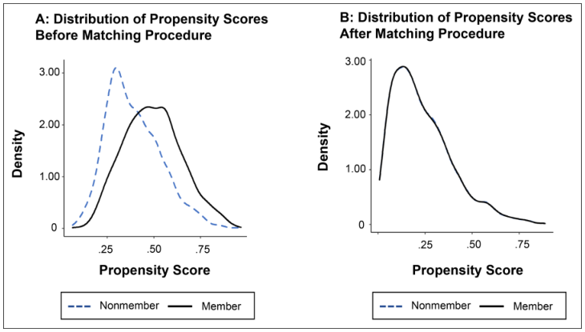

NOTE: figure/graphic rendered as an image from the PDF; its content is not machine-readable text. Caption (if any) follows as the next block.

Figure 2. Distribution of Propensity Scores Before and After Matching.

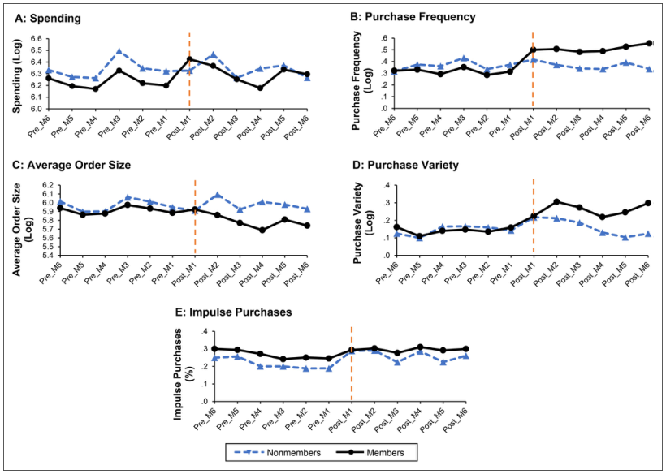

NOTE: figure/graphic rendered as an image from the PDF; its content is not machine-readable text. Caption (if any) follows as the next block.

Figure 3. Preenrollment and Postenrollment Trends of Consumers’ Purchase Behaviors. Notes: These graphical tests of common-trend assumption are based on the matched sample. The y-axes are the mean values of outcome variables from members and nonmembers in the kth month prior to their enrollment (denoted as “Pre_Mk”) and the kth month after enrollment (denoted as “Post_Mk”). The vertical dotted line represents the first month of enrollment (i.e., treatment).

Guo and Liu 879

Page 12

and Kannan 2021) that randomly assigns the matched sample to the treated group and control group and estimates the fake treatment effect with the main model. As shown in Table W3 of Web Appendix A, the signs of the treatment are not significant, further alleviating the concern that treatment effects may be biased by potential confounds.

#### Control for Selection on Unobservables with Instrumental Variable

The inclusion of fixed effects in DiD regression addresses the endogeneity of MFS enrollment by controlling for individualspecific or time-specific unobservables that influence consumers’ enrollment decisions and purchase decisions. However, there are unobserved factors that might vary across both time and individuals. One example is the ever-changing customer satisfaction with the retailer, influencing their decisions to enroll and to purchase. We use a time-varying instrumental variable combined with the control function approach to address such endogeneity (Heckman 1979; Wooldridge 2010). In the first stage, we regress a consumer’s enrollment decision on an instrumental variable, along with cohort fixed effects and time fixed effects, using a probit regression.<sup>6</sup> Specifically, we use the percentage of members who reside in the same zip code as the focal consumer in a given month as the instrumental variable. The consumers in the data reside in 256 different zip codes across the country. This instrumental variable is provided by the retailer, not calculated from our sample. In the second stage, we use the generalized residual obtained from the firststage estimation as an additional covariate in estimating the outcome equations (Equations 2a and 2b).<sup>7</sup>

The instrumental variable is correlated with the consumer enrollment decision because people around a consumer may form peer effects that influence a consumer’s decision to join a membership program (Bapna and Umyarov 2015). The more people around a consumer enroll in MFS, the higher the probability the consumer will enroll. Table W4 of Web Appendix A shows that the percentage of members is a significant predictor of whether a consumer enrolls in MFS. We test the strength of the instrumental variable using the incremental F-statistic in the first stage of regression.<sup>8</sup>

More importantly, the instrumental variable should satisfy the exclusion restrictions; that is, it has no direct effect on consumers’ purchase outcomes, and the only way it affects the outcomes is by affecting their enrollment decision (Nunn and Wantchekon 2009). It is reasonable to assume that neighbors’ enrollments

do not directly impact a consumer’s purchase outcomes. Undeniably, the percentage of members in an area may be correlated with geographic and socioeconomic features, which have been controlled with the customer-level fixed effects.

To further confirm that the exclusion restriction is satisfied, we follow previous literature and perform a falsification exercise (e.g., Ailawadi, Ma, and Grewal 2018; Nunn and Wantchekon 2009). We examine the reduced-form relationship between the percentage of members in a consumer’s zip code (the instrument) and the consumer’s purchase outcomes using a sample of consumers who purchase exclusively digital products (e.g., e-cards and e-books). Because no shipping or delivery is necessary for digital products, these consumers are not subject to any shipping policies, including MFS. Therefore, it is reasonable to assume that MFS does not apply to this sample. Suppose the instrumental variable only affects purchase outcome through MFS enrollment. In that case, we expect no relationship between the percentage of members in an area and consumer purchase outcomes for this digital-purchase-only sample after controlling for other observed variables. Indeed, Table W5 of Web Appendix A shows that the coefficient of the percentage of members is not significant for any purchase outcome variables. Therefore, we have theoretical and empirical justification for the exogeneity of our instrument variable. We conducted a series of robustness checks to test the stability of our results, described in the “Robustness Checks” section.

#### Empirical Results

We report the average and dynamic treatment effect of MFS enrollment on all outcomes for stacked DiD in Table 4. We find that the coefficients of the generalized residual from the first stage of the control function are significant for both models and across most outcomes. This finding indicates that the estimates of the treatment effects would be biased if we do not control for the endogeneity of enrollment timing. Please note that we use log-transformed dependent variables (except for impulse purchases), and the change in the outcome variables after enrollment should be interpreted with an exponential transformation of the treatment effects minus 1.

#### Consumers’ Purchase Outcome

How much to buy. We surprisingly find no significant average treatment effect on consumers’ spending during their membership period (Table 4). Our result contradicts findings in recent studies of free shipping policies, which suggest that consumers are likely to spend more with unlimited free shipping (Shehu, Papies, and Neslin 2020). To provide granular-level implications of consumers’ postenrollment purchase behaviors, we delve into consumers’ purchase frequency and average order size. We find that members’ purchase frequency increases by 17.35%, but spending per order decreases by 10.42% (−$8.49 per order) after enrollment. This change can be explained by the no-minimum free shipping effects. That is, members split large orders they previously purchased (due to the CFS threshold) into several smaller

6 Due to the lack of variation in the dependent variable across consumers in our data, identifying the individual-cohort fixed effects and cohort-time fixed effects in the first-stage model is not feasible. 7 The generalized residual, grit = Enrollmentitλ(zitδ) −(1 − Enrollmentit)λ(−zitδ) where λ(•) is the inverse Mills ratio and zit is a vector of variables included in the probit model. 8 The F-statistic is greater than 10, which meets the hurdle of criteria (Staiger and Stock 1997), indicating the correlation between the instrumental variable and endogenous enrollment decision.

880 Journal of Marketing 87(6)

Page 13

ones to take advantage of free shipping benefits, leading to insignificant changes in spending after enrollment.

When we look at the dynamic enrollment effects, the significant and positive coefficient of the two-way interaction suggests an upward trend in members’ spending over time. From these estimates and the logged time trend variable, we calculate the monthly average treatment effect over the membership period and find that the effect on spending is not statistically significant in the first six months (Table W6 of Web Appendix A). However, starting from the 7th month, the effect becomes significantly positive and gradually strengthens over time, with a 17.35% increase ($27.65 per month) in the 7th month and a 24.61% increase ($39.23 per month) in the 12th month. These changes suggest that the switching cost effect may have become stronger over time, and the increase in the switching cost effect dominates the wearing out of the sunk cost effect. We also find an upward trend in consumers’ purchase frequency and order size changes. Despite a significantly smaller order size in the first five months after enrollment and no significant change thereafter (Table W6 of Web Appendix A), members keep a high purchase frequency over time. This behavior change may benefit the retailer in the long run when the increased spending is greater than the shipping cost absorbed by the retailer.

What to buy. We find that an average consumer purchases from a broader product category after enrollment (12.75% monthly increase). The consumer purchases from two more product categories during the membership period. Moreover, the share of impulse products in consumers’ shopping baskets increases by around 3% ($.84 more spending) per month. These results indicate that no-minimum free shipping can diversify consumers’ purchases into more categories and induce more unplanned and immediate consumption needs (see Table W13 of Web Appendix A for the increases in spending decomposed by product categories).

Importantly, the enrollment effect on consumers’ purchase variety amplifies over time. Members purchase 11.63% more product categories in the first month, increasing to 17.35% in the 12th month of membership (Table W6 of Web Appendix A). As consumers develop a positive attitude toward the retailer over time due to the switching costs, they are more likely to explore other categories. These results also indicate that the incremental spending in the last several months after enrollment may be due to consumers’ variety-seeking shopping behavior. However, we do not find any significant time trend in the spending on impulse products.

Net customer revenue. Although we do not find an overall increase in consumers’ spending, we observe a monthly increase in NCR by 12.75% (an increase of $19.93 per month) (Table 4). This finding suggests that the membership fee could compensate for the increased shipping costs and is a major revenue source.<sup>9</sup> The result is consistent with real-world

Table 4. Treatment Effects of MFS Enrollment on Consumers’ Purchase Behaviors and NCR with Stacked-DiD.

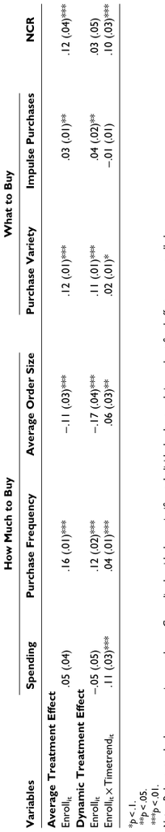

NOTE: complex table shown as an image of the PDF; the text below is a rough machine extraction and may be mis-aligned.

**extracted text (unreliable layout)**

9 We estimate the enrollment effect of MFS on revenue sources and shipping costs (see Table W12 of Web Appendix A).

Guo and Liu 881

Page 14

cases. For example, Prime membership fees accounted for 6.8% of Amazon’s annual revenue (Fareeha 2021). Costco’s revenue from membership fees accounts for 80% of its gross margin (Lewis 2016).

Moreover, there is an upward trend in this positive effect of MFS, although members do not significantly contribute to the retailer’s revenue until the second month of the membership (Table W6 of Web Appendix A). Specifically, there is a 10.25% increase in the NCR (an increase of $16.44) in month 2. It keeps increasing to 32.31% in month 12 (an increase of $50.52). This strengthened financial outcome is expected as consumers increasingly spend more with the retailer over the membership period.

#### Heterogeneity in Enrollment Effects

Understanding the heterogeneous effect of MFS enrollment is strategically important for retailers to identify and engage their best-value consumers with MFS. We next conduct a heterogeneity analysis to reveal whether and how MFS enrollment effects vary across customer segments. Prior studies have shown that the effect of membership programs might be moderated by consumers’ initial usage levels (Liu 2007), variety seeking (Zhang, Krishna, and Dhar 2000), and sensitivity to transaction costs (Kopalle et al. 2012). We thus examine the moderating effect of these consumers’ characteristics, which are measured correspondingly by their preenrollment spending (spendingi), purchase variety (purchase_varietyi), and willingness to pay shipping fees (%_orders_paying_shipping_feei), on the treatment effect of MFS. For each characteristic, we subsequently develop the expectation of its impact on spending and NCR.

Moderating effect of preenrollment spending. We posit that the treatment effects of MFS on spending and NCR might be smaller for buyers who previously spent more (i.e., heavy buyers with higher total spendingi) because of a ceiling effect. Heavy buyers might already reach their consumption limit and have less potential to increase their subsequent consumption than light buyers (Liu 2007). In contrast, light buyers are still well under their consumption “ceilings.” Once they commit to the retailer as a paid member, they are more likely to consolidate their spending with the retailer, leading to more

purchases. In addition, heavy buyers are more likely to enroll (Table W1 of Web Appendix A) to exploit free shipping benefits, resulting in less net revenue than others. Thus, we expect the treatment effect of MFS on both spending and NCR to be smaller for heavy buyers.

Moderating effect of preenrollment purchase variety. We posit that the treatment effect of MFS on spending might be larger for consumers who previously purchased from diverse product categories (i.e., those with a higher value of purchase_varietyi). The diversity of purchased product categories reflects consumers’ familiarity with the retailer, making them more likely to increase their purchases after enrollment. Moreover, consumers often have a limited budget for each product category (Heath and Soll 1996). The total budget consumers are willing to spend at the retailer could be higher for variety seekers. As a result, these consumers are more likely to respond to unlimited free shipping and spend more with the retailer.

Moderating effect of willingness to pay shipping fees. We posit that the treatment effect of MFS on spending might be stronger for consumers who are more willing to pay shipping fees (i.e., those with a higher %_orders_paying_shipping_feei). Consumers who are unwilling to pay shipping fees are more likely to accumulate large orders to avoid paying those fees under CFS. After enrollment, they may take advantage of the unlimited free shipping and break large orders into smaller ones without spending more. This purchase behavior change increases the shipping cost absorbed by the retailer and thus hurts its profit. On the contrary, consumers who are willing to pay shipping fees might purchase whenever they need and thus pay more shipping fees before enrollment. Joining the MFS could benefit them more than others because of the reduced transaction costs, leading to an increase in spending and revenue contribution.

To provide insights into the heterogeneous treatment effect across those customer segments, we interact the treatment effect with preenrollment purchase characteristics as

Yitg = θig + τtg + γ1Enrollit + γ2Enrollit × X<sup>Preenroll</sup>

i + εitg,

(4)

where X<sup>Preenroll</sup>

i = {spendingi, purchase_varietyi, %_orders_ paying_shipping_feei}. Table 5 shows the estimation results.

Table 5. Heterogeneity of MFS Enrollment Effects.

[output not shown]

NOTE: table converted from PDF layout to HTML text; cell boundaries are reconstructed. See PDF if exact alignment matters.

We find a similar moderating effect of consumers’ characteristics on their spending and NCR. As expected, the treatment effect is smaller for consumers who spent more in their preenrollment period. This result supports the existence of a ceiling effect. Moreover, the treatment effect of MFS is also more positive for consumers who previously purchased more diversely and are willing to pay shipping fees. To check the robustness of the moderating effects, we also include/exclude other interaction terms with consumers’ purchase characteristics (see Table W8 of Web Appendix A).

Heterogeneous treatment effect by customer segments. Having identified the negative moderating effect of preenrollment spending, we next ask whether any groups of consumers could potentially hurt the retailer’s revenue. To seek the answer, we split customers equally into two 3-by-3 segments based on their preenrollment spending versus their purchase variety/willingness to pay the shipping fee. We then calculate the treatment effects on the NCR for each segment according to the estimated coefficients in Equation 4. We find large variations across different segments (Table 6). In particular, MFS has the greatest effect on light buyers who are the most willing to pay shipping fees or purchase from the broadest product categories before enrollment, with a 91.55% or 55.27% monthly increase in the NCR (an increase of $64.91 or $34.86), respectively. This might be because those consumers tend to consolidate their spending after enrollment, with a much higher purchase frequency but not exploiting the free shipping benefit with a reduced order size (Web Appendix Tables W7a–W7c). On the contrary, we surprisingly find that MFS has no significant or even negative impact on the heavy buyer segment’s revenue contribution. The MFS program may lose the most money from the enrollment of heavy buyers who are the least willing to pay the shipping fee (11.31% monthly decrease in revenue or a loss of $27.13) or with the lowest purchase variety (14.79% monthly decrease in revenue or a loss of $41.71). These consumers exploit free shipping benefits by splitting large orders into smaller ones or purchasing from categories with a lower price level (Web

Appendix Table W7c). Moreover, they either do not change their total spending after enrollment because of the ceiling effects or even reduce their purchase as they no longer need to purchase filler items to meet the free shipping threshold under CFS (Web Appendix Table W7a). Since these members bring more shipping costs to the retailer without increased spending, their enrollment could have a detrimental effect on the retailer’s revenue.

#### Additional Analysis and Robustness Checks Customer Retention with MFS

As online shoppers can purchase anywhere, retailers expect MFS to help them lock valuable consumers into their economic loop and reduce their switching to competitors (Boudet, Huang, and Von Difloe 2020). More importantly, customer retention is closely tied to retailers’ profitability because retaining existing customers costs less than acquiring new ones (Gupta, Lehmann, and Stuart 2004). In addition, existing customers tend to purchase more, pay higher prices, and have positive word of mouth, benefiting retailers in the long run (Bolton, Lemon, and Verhoef 2004). Prior literature on shipping fee structure suggests that free shipping is effective in acquiring new consumers and encouraging repeated buying (Lewis 2006). Still, little is known about how it impacts the retention of existing customers. Given the importance of retention for both practitioners and researchers, we investigate whether MFS enhances customer retention.

To this end, we construct a variable, churn ∈{0, 1}, to indicate whether a consumer had churned during the observation period. We follow the retailer’s definition of a churned customer, that is, there has been no record of the consumer’s transaction, including purchases and MFS membership enrollment/ renewal, for at least one year. We obtained additional data from the retailer on whether each consumer churned during the sample period. We only include consumers who could possibly churn during our sample period. Members who enrolled late (i.e., after the 24th month) are active customers by

Table 6. Heterogeneity of MFS Enrollment Effects on NCR by Customer Segments.

[output not shown]

NOTE: table converted from PDF layout to HTML text; cell boundaries are reconstructed. See PDF if exact alignment matters.

*p < .1. **p < .05. ***p < .01. Notes: We divided consumers into two three-by-three metrics by the tercile of their preenrollment spending levels versus willingness to pay shipping fee/purchase variety. Estimations and standard errors are calculated on the basis of the estimates of Equation 4.

Guo and Liu 883

Page 16

definition, as they are still within a one-year membership period in our data. We thus excluded them from this analysis. As a result, our sample only includes early members who enrolled in the 23rd and 24th months, the first two months after the MFS launch, and their paired nonmembers. We observe these consumers’ decisions on membership renewal and whether to churn, which is essential for the retention analysis. In this sample, 74.89% of members renewed their membership, and the average churn rate of members and nonmembers is 5.76% and 29.61% in the observation period, respectively.

We adopt a linear probability DiD model (Pattabhiramaiah, Overby, and Xu 2021) with the same identification strategy as the main model, that is, a stacked specification with matching and control function approach, to capture the effect of MFS on customer retention:

Churnitg = θig + τtg + αEnrollit + εitg. (5)

The parameter of Enrollit captures the treatment effect of MFS on retention. Table 7 shows that MFS enrollment has a significant effect on customer retention. Specifically, the churn probability is 18% lower for consumers who enrolled in MFS than for nonmembers. The rationale is that members might experience higher switching costs than nonmembers due to the convenience of free shipping. However, findings in this analysis are only applicable to early adopters of MFS, and we may not be able to generalize them to later adopters.

To examine whether MFS is more effective in increasing the retention of specific types of consumers, we included a few interactions of consumer characteristics and the treatment effect term in the model. We find a greater reduction in the churn probability among members who are variety seekers, that is, those who purchased from broader product categories before enrollment (Table 7). This might be because they benefit the most from MFS enrollment, as unlimited free shipping facilitates their purchases from various product categories with different price levels. As those consumers become accustomed to the unlimited free shipping, the cognitive effort to search for equivalent alternatives will increase, building the barriers to leaving (Murray and Häubl 2007). However, we do not find that MFS increases retention among consumers with other characteristics.

#### Robustness Checks

Alternative explanation on renewal effect. Consumers may increase their purchases over time because they want to get the most out of their last months of membership. If that is the case, we would observe a decrease in their purchases after the 12-month membership period, especially for those who choose not to renew their membership. We estimate Equation 2a with data extended to the months after the membership ends and find no significant difference between members’ monthly spending in the last quarter of the membership period and the first quarter after the membership expires (Table W9 of Web Appendix A). More important, there is no significant difference in the first-quarter spending after the membership expires between members who renewed and those who did not renew. These findings suggest that the effect of MFS goes beyond the membership period, ruling out the alternative explanation.

Alternative specifications of DiD model. First, we check our results with conventional TWFE-DiD. The coefficients of interest are consistent with the stacked DiD model, but the magnitudes of these treatment effects are slightly different (Table W10 of Web Appendix A) due to the possible bias caused by the stacked treatment (Baker, Larcker, and Wang 2022). Secondly, we estimate the treatment effects without controlling the selection on the unobservables. The results are largely consistent, yet with slightly greater magnitudes than the ones of the main model (Table W10 of Web Appendix A). It suggests that without controlling for the selection on unobservables, the estimates could be biased upward. Thirdly, we also ran a classic leads–lags DiD model (Pattabhiramaiah, Overby, and Xu 2021; Xu et al. 2017). The specification is similar to the specification shown in Equation 2a, except that we replaced αEnrollit with −2

ρτEnrollit+τ. We use the τ = −1 term as

a baseline to avoid the dummy variable trap (Pattabhiramaiah, Overby, and Xu 2021). Figure W3 of Web Appendix A presents the results of the treatment effects of each preenrollment and postenrollment month. We observe that most preenrollment estimates contain zero in their confidence intervals, whereas the postenrollment estimates largely align with our dynamic treatment effect in Table W6 of Web Appendix A.

Table 7. Treatment Effects of MFS Enrollment on Customer Retention.

[output not shown]

NOTE: table converted from PDF layout to HTML text; cell boundaries are reconstructed. See PDF if exact alignment matters.

*p < .1. **p < .05. ***p < .01. Notes: Robust standard errors are in parentheses. Generalized residuals are significant. Individual-cohort and time-cohort fixed effects are controlled.

884 Journal of Marketing 87(6)

Page 17

Alternative matching algorithms. We find robust results with different matching algorithms, including (1) the 1:1 matching without replacement; (2) matching with a bigger caliper size of .25 times the standard deviation of propensity scores to test the stability of results under a more relaxed matching requirement; and (3) the 1:3 nearest-neighbors matching to check whether the results are sensitive to more than one matched control consumer (Xu et al. 2017). Table W10 of Web Appendix A reports the enrollment effects modeled with these robustness checks. The coefficients of interest are consistent with our baseline model.

Hazard model for customer retention. To address the rightcensored problem, we use a proportional hazard model (Cox and Oakes 1996) to quantify the effect of MFS on customer retention. We use the same model specifications as the main model, that is, a stacked specification with matching and a control function approach. Table W11 of Web Appendix A shows that the hazard model results are consistent with our main result on retention.

#### Conclusions and Implications

An increasing number of retailers have adopted MFS with an expectation to balance the free shipping required by consumers and the need to recover shipping costs. However, the effectiveness of MFS is still under debate. In collaboration with a top online retailer that experimented with MFS, our study takes the first step to systematically examine the effects of MFS on consumers’ purchase behaviors, retailers’ financial outcomes, and customer retention.

#### Theoretical Implications

Our study advances three major themes in the marketing literature. First, we add to the shipping policy literature by investigating an emerging shipping policy, MFS. Lewis (2006) and Lewis, Singh, and Fay (2006) demonstrate that temporary free shipping promotions can successfully increase order incidence but lead to smaller order sizes. Our results support this finding in the context in which retailers offer unlimited free shipping for members and CFS for nonmembers. While Shehu, Papies, and Neslin (2020) show that consumers spend more with temporary free shipping promotions, we find that an average MFS member may not initially purchase more but does so over time. Besides the expenditure, Lewis (2006) and Shehu, Papies, and Neslin (2020) find that free shipping might hurt retailers’ financial outcomes as the increased sales cannot offset the lost shipping revenue and other associated costs. However, our findings suggest that in the context of MFS, the upfront membership fee is an important revenue source and can compensate for the shipping costs. The profitability of MFS may vary across customer segments due to their different behavior change. Although heavy buyers have long been treated as the most valuable customers for relationship management

(Liu 2007), we find that those customers may not be as profitable for the MFS program as expected. This is because when heavy buyers exploit the unlimited free shipping benefit, they do not spend more but significantly increase the shipping costs absorbed by retailers. In contrast, MFS effectively enhances light and moderate buyers’ purchase and revenue contribution. These findings also reconcile prior inconclusive results on the profitability of MFS from theoretical studies, which suggest that the adoption of MFS could make retailers either gain (Sun, Cavusoglu, and Raghunathan 2022) or lose (Fang et al. 2021). Furthermore, our work adds to this stream of literature by examining the effect of free shipping on purchased product types. Shehu, Papies, and Neslin suggest that free shipping would encourage purchases from high-risk product categories. Our study focuses on other aspects of product types and reveals that free shipping leads to purchases from more diverse product categories, especially impulse products.

Second, our research contributes to the literature on membership programs (e.g., loyalty and subscription programs) by showing the dynamic changes in consumers’ purchase behaviors over the membership period. According to prior studies, the sunk cost effect of initial investment (e.g., Ailawadi, Ma, and Grewal 2018; Iyengar, Park, and Yu 2022) and the switching cost effect of cumulated rewards (e.g., Lewis 2004; Zhang and Breugelmans 2012) might be the drivers of consumers’ subsequent repurchase decisions. Moreover, these effects may change over time. For example, Iyengar, Park, and Yu (2022) study a subscription program with member-only price discounts and gift cards being the most important benefits and find that the increase in consumer spending is the strongest in the first month after enrollment and decreases over time. This is because the effect of sunk cost on a consumer’s mental account wears off after the initially escalated commitment. On the contrary, we show that the treatment effect of MFS increases over time. Our findings suggest that the switching cost caused by free shipping benefits and membership fees might become more salient over time. It might dominate the wearing out of the sunk cost effect, as the members enjoy the ease of shopping and gradually become more engaged and committed to the retailer.

Finally, we add to the customer retention literature (e.g., Bolton, Kannan, and Bramlett 2000; Lewis 2004). Prior research investigates the effectiveness of various marketing tactics on customer retention, such as customer relationship management (e.g., Bolton, Kannan, and Bramlett 2000; Verhoef 2003), targeted marketing campaigns (Ascarza 2018), and price discounts (Lewis 2006). We extend this work by empirically revealing the positive effect of MFS on customer retention regarding the length of the relationship. Moreover, we find that MFS is especially effective in preventing churn in consumers who would like to shop in diverse product categories.

#### Managerial Implications

From a managerial perspective, our study demonstrates that MFS is an effective shipping policy to solve retailers’ free shipping dilemma. MFS can enhance retailers’ revenue as the

Guo and Liu 885

Page 18

membership fees could recoup the shipping costs. Moreover, our study suggests that consumers are more likely to exploit their unlimited free shipping benefits at the beginning of enrollment. In this period, consumers break large orders into smaller ones without increasing their total spending. Retailers may not gain incremental revenue due to the reduced profit margin and increased shipping costs. However, the free shipping benefit builds a switching barrier that motivates consumers to purchase more frequently with larger order sizes over time. It eventually leads to increased spending and revenue contribution. Such dynamic changes in purchase behaviors suggest that the MFS program may help consumers form a positive perception of the retailer and transform consumers’ occasional purchases into repeat patronage behaviors.

Next, MFS might have different, even opposite, effects on revenue across customer segments. Managers should pay attention to the diverse responses from various customer segments to ensure the overall profitability of MFS. Conventionally, retailers treat heavy buyers who spent the most before enrollment as the best customer segment. In contrast to this view, our study supports the argument of the heavy buyer fallacy that these consumers are less likely to contribute additional revenue due to their consumption ceiling (Lal and Bell 2003). Heavy buyers can even bring negative revenue to the MFS program if they are unwilling to pay shipping fees or have low purchase variety during the preenrollment period. These consumers often take advantage of the unlimited free shipping without spending more, resulting in greatly increased shipping costs to the retailer. Instead, light buyers, especially those willing to pay shipping fees or variety seekers, are the groups with greater potential to increase their revenue contribution after enrollment. Free shipping motivates them to consolidate their spending. When promoting the MFS program, managers should reallocate the marketing resources to target and encourage the more responsive customer segments to enroll.

#### Limitations

Several limitations of this study could be investigated in future studies. First, our study investigates how free shipping as the only paid membership benefit changes consumers’ purchase behaviors and the ultimate revenue. However, some retailers tend to add additional benefits to the MFS program subsequently, such as streaming service on its own or partner platforms and premium customer service. Consumers’ perceived value of MFS may differ for these subscription programs with added major perks. Therefore, our findings may not be generalized to retailers that offer other major perks on top of MFS. Second, the effect size of MFS on consumers’ purchases may change with membership fees and the CFS threshold. For example, a lower free shipping threshold may result in smaller effects of MFS as the unlimited free shipping benefit becomes less attractive. A higher membership fee may prompt members to purchase more to make their investment worthwhile. The ratio of the CFS threshold to membership fees offered by the retailer in this study is about 1:3. It is comparable

with its local competitors and giant retailers in the United States, such as Walmart. Our empirical results can be generalized to retailers with a similar ratio of these fees. Future studies could investigate to what extent the changes in such a ratio may lead to different findings. Lastly, we focus on the effect of MFS on customer retention, but factors that impact customers’ membership renewal and cancellation decisions also have significant managerial implications. We leave these analyses as a fruitful topic for future research.

Acknowledgments

The authors would like to thank the review team for their insightful suggestions. They also gratefully acknowledge Alina Sorescu, P.K. Kannan, Shrihari (Hari) Sridhar, and Venkatesh (Venky) Shankar for their constructive comments.

Associate Editor

Jie Zhang

Declaration of Conflicting Interests

The author(s) declared no potential conflicts of interest with respect to the research, authorship, and/or publication of this article.

Funding

The author(s) received no financial support for the research, authorship, and/or publication of this article.

References

Ailawadi, Kusum, Yu Ma, and Dhruv Grewal (2018), “The Club Store

Effect: Impact of Shopping in Warehouse Club Stores on Consumers’ Packaged Food Purchases,” Journal of Marketing Research, 55 (2), 193–207. Ali, Fareeha (2021), “Amazon Prime Reaches 200 Million Members

Worldwide,” Digital Commerce 360 (April 16), https://www. digitalcommerce360.com/2021/04/16/amazon-prime-reaches-200- million-members-worldwide/. Amazon (2022), “Annual Report,” https://www.annualreports.com/

Company/amazoncom-inc. Ansari, Asim, Carl F. Mela, and Scott A. Neslin (2008), “Consumer

Channel Migration,” Journal of Marketing Research, 45 (1), 60–76. Ascarza, Eva (2018), “Retention Futility: Targeting High-Risk

Customers Might Be Ineffective,” Journal of Marketing Research, 55 (1), 80–98. Ashley, Christy, Erin A. Gillespie, and Stephanie M. Noble (2016),

“The Effect of Loyalty Program Fees on Program Perceptions and Engagement,” Journal of Business Research, 69 (2), 964–73. Baker, Andrew C., David F. Larcker, and Charles C.Y. Wang (2022),

“How Much Should We Trust Staggered Difference-in-Differences Estimates?” Journal of Financial Economics, 144 (2), 370–95. Bapna, Ravi and Akhmed Umyarov (2015), “Do Your Online Friends

Make You Pay? A Randomized Field Experiment on Peer Influence in Online Social Networks,” Management Science, 61 (8), 1741–2011. Bolton, Ruth N., P.K. Kannan, and Matthew D. Bramlett (2000),

“Implications of Loyalty Program Membership and Service

886 Journal of Marketing 87(6)

Page 19

Experiences for Consumer Retention and Value,” Journal of the Academy of Marketing Science, 28 (1), 95–108. Bolton, Ruth N., Katherine N. Lemon, and Peter C. Verhoef (2004),

“The Theoretical Underpinnings of Customer Asset Management: A Framework and Propositions for Future Research,” Journal of the Academy of Marketing Science, 32 (3), 271–92. Boudet, Julien, Jess Huang, and Ryter von Difloe (2020), “Coping with the

Big Switch: How Paid Loyalty Programs Can Help Bring Consumers Back to Your Brand,” McKinsey & Company (October 22), https:// www.mckinsey.com/capabilities/growth-marketing-and-sales/ourinsights/coping-with-the-big-switch-how-paid-loyalty-programscan-help-bring-consumers-back-to-your-brand. Callaway, Brantly and Pedro H.C. Sant’Anna (2021), “Difference-in-Differences with Multiple Time Periods,” Journal of Econometrics, 225 (2), 200–230. Cengiz, Doruk, Arindrajit Dube, Attila Lindner, and Ben Zipperer

(2019), “The Effect of Minimum Wages on Low-Wage Jobs,” Quarterly Journal of Economics, 134 (3), 1405–54. Chen, Chaoqun and Donald Ngwe (2017), “Shipping Fees and Product

Assortment in Online Retail,” working paper, Harvard Business School, Harvard University. Comscore (2014), “Study: Consumers Demand More Flexibility When

Shopping Online,” press release (June 11), https://www.comscore. com/Insights/Press-Releases/2014/6/Study-Consumers-Demand-More- Flexibility-When-Shopping-Online. Cox, David Roxbee and David Oakes (1996), Analysis of Survival

Data. Chapman & Hall. Dawson, Sandy and Minjeong Kim (2009), “External and Internal

Trigger Cues of Impulse Buying Online,” Direct Marketing: An International Journal, 3 (1), 20–34. Dick, Alan S. and Kunal Basu (1994), “Consumer Loyalty: Toward an

Integrated Conceptual Framework,” Journal of the Academy of Marketing Science, 22 (2), 99–113. Dick, Alan S. and Kenneth R. Lord (1998), “The Impact of Membership

Fees on Consumer Attitude and Choice,” Psychology and Marketing, 15 (1), 41–58. Fang, Zhen, Yi-Chun (Chad) Ho, Xue Tan, and Yong Tan (2021),

“Show Me the Money: The Economic Impact of Membership-Based Free Shipping Programs on E-Tailers,” Information Systems Research, 32 (4), 1115–27. Freedman, Lauren (2022), “The Shopper Speaks: Is Free Shipping Still

Everything to Online Shoppers,” Digital Commerce 360 (September 22), https://www.digitalcommerce360.com/2022/09/ 22/the-shopper-speaks-is-free-shipping-still-everything-to-onlineshoppers/. Frischmann, Tanja, Oliver Hinz, and Bernd Skiera (2012), “Retailers’

Use of Shipping Cost Strategies: Free Shipping or Partitioned Prices?” International Journal of Electronic Commerce, 16 (3), 65–88. Golder, Peter N., Marnik G. Dekimpe, Jake T. An, Harald J. van

Heerde, Darren S.U. Kim, and Joseph W. Alba (2023), “Learning from Data: An Empirics-First Approach to Relevant Knowledge Generation,” Journal of Marketing, 87 (3), 319–36. Goodman-Bacon, Andrew (2021), “Difference-in-Differences with

Variation in Treatment Timing,” Journal of Econometrics, 225 (2), 254–77.

Gu, Xian and P.K. Kannan (2021), “The Dark Side of Mobile App

Adoption: Examining the Impact on Consumers’ Multichannel Purchase,” Journal of Marketing Research, 58 (2), 246–64. Gupta, Sunil, Donald R. Lehmann, and Jennifer Ames Stuart (2004),

“Valuing Customers,” Journal of Marketing Research, 41 (1), 7–18. Heath, Chip (1995), “Escalation and De-Escalation of Commitment in

Response to Sunk Costs: The Role of Budgeting in Mental Accounting,” Organizational Behavior and Human Decision Processes, 62 (1), 38–54. Heath, Chip and Jack B. Soll (1996), “Mental Budgeting and Consumer

Decisions,” Journal of Consumer Research, 23 (1), 40–52. Heckman, James J. (1979), “Sample Specification Bias as a Selection

Error,” Econometrica, 47 (1), 153–61. Henderson, Conor M., Joshua T. Beck, and Robert W. Palmatier

(2011), “Review of the Theoretical Underpinnings of Loyalty Programs,” Journal of Consumer Psychology, 21 (3), 256–76. Iyengar, Raghuram, Young-Hoon Park, and Qi Yu (2022), “The

Impact of Subscription Programs on Customer Purchases,” Journal of Marketing Research, 59 (6), 1101–19. Khan, Uzma and Ravi Dhar (2010), “Price-Framing Effects on the

Purchase of Hedonic and Utilitarian Bundles,” Journal of Marketing Research, 47 (6), 1090–99. Kopalle, Praveen K., Yacheng Sun, Scott A. Neslin, Baohong Sun, and

Vanitha Swaminathan (2012), “The Joint Sales Impact of Frequency Reward and Customer Tier Components of Loyalty Programs,” Marketing Science, 31 (2), 216–35. Lal, Rajiv and David E. Bell (2003), “The Impact of Frequent Shopper

Programs in Grocery Retailing,” Quantitative Marketing and Economics, 1, 179–202. Leenheer, Jorna, Harald J. Van Heerde, Tammo H.A. Bijmolt, and

Ale Smidts (2007), “Do Loyalty Programs Really Enhance Behavioral Loyalty? An Empirical Analysis Accounting for Self-Selecting Members,” International Journal of Research in Marketing, 24 (1), 31–47. Lewis, Michael (2004), “The Influence of Loyalty Programs and

Short-Term Promotions on Consumer Retention,” Journal of Marketing Research, 41 (3), 281–92. Lewis, Michael (2006), “The Effect of Shipping Fees on Consumer

Acquisition, Consumer Retention, and Purchase Quantities,” Journal of Retailing, 82 (1), 13–23. Lewis, Michael, Vishal Singh, and Scott Fay (2006), “An Empirical

Study of the Impact of Nonlinear Shipping and Handling Fees on Purchase Incidence and Expenditure Decisions,” Marketing Science, 25 (1), 51–64. Lewis, Robin (2016), “‘Costcoholics’: Costco’s $113.7 Billion

Addicts,” Forbes (February 16), https://www.forbes.com/sites/ robinlewis/2016/02/16/costcoholics-costcos-113-7-billion-addicts/. Liu, Yuping (2007), “The Long-Term Impact of Loyalty Programs on

Consumer Purchase Behavior and Loyalty,” Journal of Marketing, 71 (4), 19–35. Liu, Yuping and Rong Yang (2009), “Competing Loyalty Programs:

Impact of Market Saturation, Market Share, and Category Expandability,” Journal of Marketing, 73 (1), 93–108. Meyer, Bruce D. (1995), “Natural and Quasi-Experiments in Economics,”

Journal of Business & Economic Statistics, 13 (2), 151–61.

Guo and Liu 887

Page 20

Murray, Kyle B. and Gerald Häubl (2007), “Explaining Cognitive

Lock-in: The Role of Skill-Based Habits of Use in Consumer Choice,” Journal of Consumer Research, 34 (1), 77–88. Narasimhan, Chakravarthi, Scott A. Neslin, and Subrata K. Sen (1996),

“Promotional Elasticities and Category Characteristics,” Journal of Marketing, 60 (2), 17–30. Nunn, Nathan and Leonard Wantchekon (2009), “The Slave Trade and

the Origins of Mistrust in Africa,” American Economic Review, 101 (7), 3221–52. Pattabhiramaiah, Adithya, Eric Overby, and Lizhen Xu (2021),

“Spillovers from Online Engagement: How a Newspaper Subscriber’s Activation of Digital Paywall Access Affects Her Retention and Subscription Revenue,” Management Science, 68 (5), 3528–48. Rook, Dennis W. and Robert J. Fisher (1995), “Normative Influences

on Impulsive Buying Behavior,” Journal of Consumer Research, 22 (3), 305–13. Rook, Dennis W. and Stephen J. Hoch (1985), “Consuming Impulses,”

in Advances in Consumer Research, Vol. 12, Elizabeth C. Hirschman and Moris B. Holbrook, eds. Association for Consumer Research, 23–27. Rosenbaum, Paul R. and Donald B. Rubin (1983), “The Central Role

of the Propensity Score in Observational Studies for Causal Effects,” Biometrika, 70 (1), 41–55. Rothschild, Michael (1974), “Searching for the Lowest Price When the

Distribution of Prices Is Unknown,” Journal of Political Economy, 82 (4), 689–711. Shehu, Edlira, Dominik Papies, and Scott A. Neslin (2020), “Free

Shipping Promotions and Product Returns,” Journal of Marketing Research, 57 (4), 640–58. Srinivasan, Shuba, Koen Pauwels, Dominique M. Hanssens, and Marnik

G. Dekimpe (2004), “Do Promotions Benefit Manufacturers, Retailers, or Both?” Management Science, 50 (5), 617–29. Staiger, Douglas and James H. Stock (1997), “Instrumental Variables

Regression with Weak Instruments,” Econometrica, 65 (3), 557–86.

Statista (2022), “Leading Reasons for Abandonment During Checkout

in the U.S. 2022,” (accessed June 24, 2022), https://www.statista. com/statistics/1228452/reasons-for-abandonments-during-checkoutunited-states/. Sun, Geng, Huseyin Cavusoglu, and Srinivasan Raghunathan (2022),

“Value of Membership-Based Free Shipping in Online Retailing: Impact of Upstream Pricing Model,” Production and Operations Management, 31 (11), 4131–53. Tuttle, Brad (2013), “Amazon Prime: Bigger, More Powerful,

More Profitable Than Anyone Imagined,” Time (March 18), https://business.time.com/2013/03/18/amazon-prime-bigger-morepowerful-more-profitable-than-anyone-imagined/. Verhoef, Peter C. (2003), “Understanding the Effect of Customer

Relationship Management Efforts on Customer Retention and Customer Share Development,” Journal of Marketing, 67 (4), 30–45. Wagner, Laura, Catarina Pinto, and Pedro Amorim (2021), “On the

Value of Subscription Models for Online Grocery Retail,” European Journal of Operational Research, 294 (3), 874–94. Wooldridge, Jeffrey M. (2010), Econometric Analysis of Cross Section

and Panel Data. MIT Press. Xu, Kaiquan, Jason Chan, Anindya Ghose, and Sang Pil Han (2017),

“Battle of the Channels: The Impact of Tablets on Digital Commerce,” Management Science, 63 (5), 1469–92. Yang, Yinghui, Skander Essegaier, and David R. Bell (2005), “Free

Shipping and Repeat Buying on the Internet: Theory and Evidence,” working paper. Yang, Zhilin and Robin T. Peterson (2004), “Consumer Perceived

Value, Satisfaction, and Loyalty,” Psychology & Marketing, 21 (10), 799–822. Zhang, Jie and Els Breugelmans (2012), “The Impact of an Item-Based

Loyalty Program on Consumer Purchase Behavior,” Journal of Marketing Research, 49 (1), 50–65. Zhang, Z. John, Aradhna Krishna, and Sanjay K. Dhar (2000),

“The Optimal Choice of Promotional Vehicles: Front-Loaded or Rear-Loaded Incentives?” Management Science, 46 (3), 348–62.

888 Journal of Marketing 87(6)

Page 21